# STLM

Time Series

STLM for Time Series Data

Yeongeun Jeon , Jung In Seo  
06-22-2021

- Data 출처 : [Data Mining for Business Analytics](https://www.dataminingbook.com/book/r-edition)에서 사용한 미국 철도 회사 “Amtrak”에서 수집한 1991년 1월~2004년 3월까지 매달 환승 고객 수

# **Introduction**

- 시계열 데이터는 추세(Trend), 계절성(Seasonal), 오차(Remainder) 세 가지 요소로 분해할 수 있다.
  - 분해는 시계열 데이터를 이해하는 데 도움이 되며, 시간에 따른 변화를 살펴볼 때 유용하다.
- 특히, `STL (Seasonal and Trend decomposition using Loess)` 분해는 다양한 상황에서 사용할 수 있는 강력한 시계열 분해 기법이다.
- 이러한 STL 기법에 덧셈 분해를 가정하여 STLM 모형은 시계열 데이터를 다음과 같이 분해한다.

$$\begin{align}
Y_{t} = S_{t} + A_{t}
\end{align}$$

- $S_{t}$ : 계절 성분(Seasonal Component)
- $A_{t}$ : 추세 + 오차 성분(Seasonally Adjusted Component)
- STLM은 $S_{t}$와 $A_{t}$를 각각 예측하고, 두 예측값을 더한 것을 최종 예측값으로 사용한다.
  - $S_{t}$는 계절 성분이 변하지 않거나 엄청 느리고 변하는 상황을 가정하고 `Seasonal naive method`을 이용하여 예측한다.
    - Seasonal naive method : 예측값 = 같은 계절(Season)의 마지막 관측값
  - $A_{t}$는 `시계열 모형`을 이용하여 적합한 후 예측한다.

## **Seasonal Naive Method**

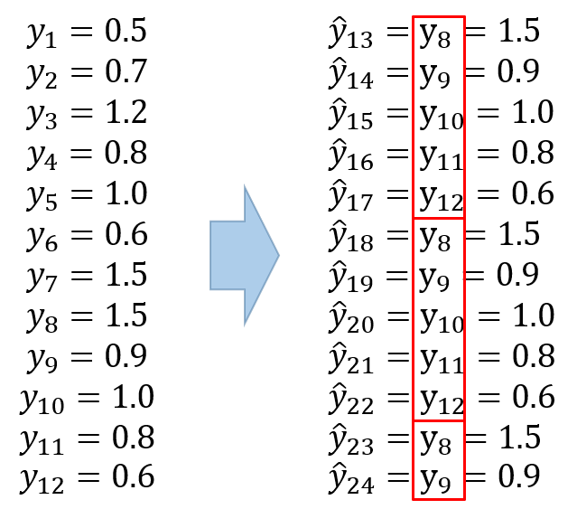

# **Appication**

- Ridership on Amtrak Trains(미국 철도 회사 “Amtrak”에서 수집한 1991년 1월~2004년 3월까지 매달 환승 고객 수) 예제를 이용하여 STLM이 실제 데이터에 어떻게 적용되는지 설명한다.

## **Data 불러오기**

```
pacman::p_load("forecast", "dplyr", "ggplot2", "xts")

# In Mac
# guess_encoding("Amtrak.csv")
# Amtrak.data <- read.csv("Amtrak.csv", fileEncoding="EUC-KR")

Amtrak.data <- data.table::fread(paste(getwd(),"Amtrak.csv", sep="/"))
ridership.ts <- ts(Amtrak.data$Ridership, start=c(1991,1), end=c(2004,3), freq=12)
```

## **Data 분할**

```
train.ts     <- window(ridership.ts,start=c(1991,1), end=c(2001,3))   # Training Data
test.ts      <- window(ridership.ts,start=c(2001,4))                  # Test Data
n.test       <- length(test.ts)
```

## **분해(Decomposition)**

- R 함수 `stl()`을 이용하여 데이터를 추세와 계절성, 불규칙 성분으로 나눌 수 있다.
  - 만약 시계열 데이터가 다중 계절성을 가진다면, `mstl()`을 이용한다.

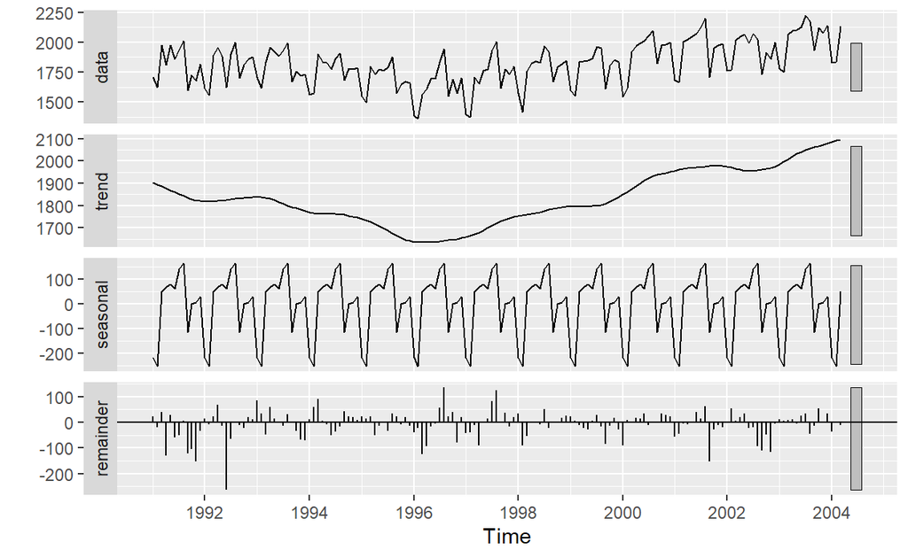

```
ridership.ts %>%
  stl( s.window = "periodic", robust = TRUE) %>%
  autoplot()
```

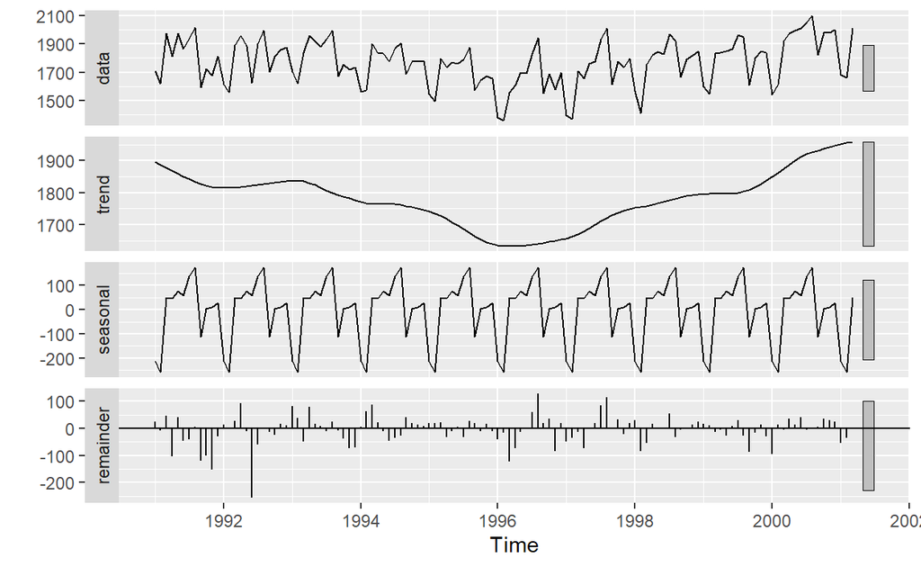

```
train.ts %>%
  stl( s.window = "periodic", robust = TRUE) %>%
  autoplot()
```

## **모형 적합**

- `forecast` package에 있는 `stlm()`을 이용하여 모형을 적합시킬 수 있다.
- `stlm()`의 자세한 옵션 설명은 [여기](https://www.rdocumentation.org/packages/forecast/versions/8.15/topics/forecast.stl)를 참조하며, 함수 구조는 [여기](https://github.com/robjhyndman/forecast/blob/master/R/mstl.R)를 참조한다.

```
stlm(y, s.window, robust, method=c("ets", "arima"),  modelfunction, xreg )
```

- y : 시계열 데이터
- s.window : `계절 성분을 추출`하기 위한 모수로 계절패턴이 시간에 따라 일정하다고 판단되면 `"periodic" 혹은 7이상의 수`를, 계절패턴이 시간의 흐름에 따라 변화된다고 판단되면 최근 데이터만 사용하도록 `작은 수`를 입력
- robust : loess 과정 에서 강력한 적합(fitting)이 사용되는지 여부
- method : 추세 + 오차 성분에 적용할 시계열 분석방법
- modelfunction : 추세 + 오차 성분을 분석하기 위해 method에 없는 시계열 방법을 함수문으로 명시
- xreg : `method=arima` 일 때, `auto.arima`에 사용될 예측변수

[output not shown]

```
$stl
             Data    Trend    Seasonal12    Remainder
Jan 1991 1708.917 1869.425 -189.19036235   28.6823492
Feb 1991 1620.586 1860.032 -240.97648277    1.5299997
Mar 1991 1972.715 1850.640   59.47573708   62.5993099
Apr 1991 1811.665 1841.247   54.32026362  -83.9026866
May 1991 1974.964 1833.126   87.92725969   53.9112002
Jun 1991 1862.356 1825.004   15.43986583   21.9124768
Jul 1991 1939.860 1816.882  134.89706721  -11.9188417
Aug 1991 2013.264 1809.662  204.56513119   -0.9632646
Sep 1991 1595.657 1802.442 -118.81826378  -87.9672285
Oct 1991 1724.924 1795.223   -7.40863825  -62.8902130
Nov 1991 1675.667 1790.281  -20.94370798  -93.6705180
Dec 1991 1813.863 1785.340   24.79248866    3.7309106
Jan 1992 1614.827 1780.398 -191.21787993   25.6469044
Feb 1992 1557.088 1782.084 -242.86167620   17.8658592
Mar 1992 1891.223 1783.770   57.11434230   50.3389993
Apr 1992 1955.981 1785.455   52.32761168  118.1978885
May 1992 1884.714 1792.392   86.53558379    5.7868514
Jun 1992 1623.042 1799.328   18.02650317 -194.3121330
Jul 1992 1903.309 1806.264  137.23971099  -40.1944058
Aug 1992 1996.712 1810.635  205.52731962  -19.4506939
Sep 1992 1703.897 1815.007 -118.04720664    6.9371530
Oct 1992 1810.000 1819.379   -5.77494231   -3.6037907
Nov 1992 1861.601 1824.082  -19.81673954   57.3360665
Dec 1992 1875.122 1828.785   25.36770427   20.9696827
Jan 1993 1705.259 1833.488 -193.28231677   65.0537637
Feb 1993 1618.535 1832.976 -244.76075685   30.3198177
Mar 1993 1836.709 1832.464   54.76209234  -50.5174176
Apr 1993 1957.043 1831.953   50.37489760   74.7153910
May 1993 1917.185 1824.316   85.21463880    7.6548541
Jun 1993 1882.398 1816.678   20.71240377   45.0072934
Jul 1993 1933.009 1809.041  139.71015039  -15.7422489
Aug 1993 1996.167 1803.023  206.62923467  -13.4857245
Sep 1993 1672.841 1797.006 -117.12449191   -7.0403892
Oct 1993 1752.827 1790.988   -4.00487339  -34.1563991
Nov 1993 1720.377 1785.162  -18.56868270  -46.2161648
Dec 1993 1734.292 1779.335   26.01683361  -71.0602561
Jan 1994 1563.365 1773.509 -197.00000572  -13.1439918
Feb 1994 1573.959 1771.119 -247.73735656   50.5773637
```

[output cut: 192 more lines]

```
              Nov          Dec
1991  -47.9796450   71.0746949
1992   73.6659746    1.1703730
1993  -35.3642418  -46.4327871
1994   19.0865322  -25.0696826
1995   25.0375925  -41.9380286
1996  -98.6078441   47.0810003
1997  -25.8392189   23.6199486
1998   39.4390972   18.9004504
1999   76.5404907   -8.0613636
2000   31.0638277    4.7058357
2001

attr(,"class")
[1] "stlm"
```

- stl : STL분해를 사용한 결과
- model : 추세 + 오차 성분에 모형 적합 결과
- x : 원 시계열 데이터
- m : 계절 주기
- fitted : 추세 + 오차 성분에 모형 적합 결과(model) + 원 계절성분 (Original Seasonal Component)
- residuals : x-fitted

## **예측**

- `추세 + 오차 성분에 ETS, ARIMA 등과 같은 모형을 적합`시킨 후 `forecast` 함수를 이용해 예측하고 `계절 성분은 Seasonal naive method을 이용해 예측`한다.

[output not shown]

```
          Jan      Feb      Mar      Apr      May      Jun      Jul
2001                            1997.937 2031.588 2021.470 2124.009
2002 1725.806 1688.820 1989.003 1997.937 2031.588 2021.470 2124.009
2003 1725.806 1688.820 1989.003 1997.937 2031.588 2021.470 2124.009
2004 1725.806 1688.820 1989.003
          Aug      Sep      Oct      Nov      Dec
2001 2159.745 1841.005 1974.640 1964.676 1992.561
2002 2159.745 1841.005 1974.640 1964.676 1992.561
2003 2159.745 1841.005 1974.640 1964.676 1992.561
2004
```

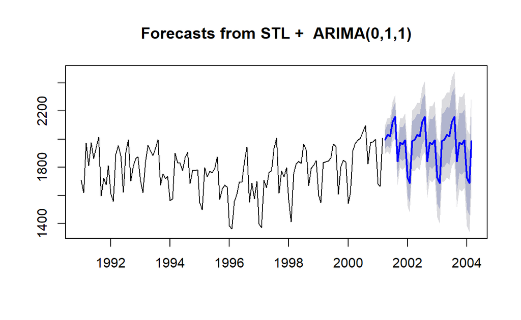

```
plot(STLM.forecast)
```

```
accuracy(test.ts, STLM.forecast$mean)
```

```
                ME     RMSE      MAE      MPE     MAPE     ACF1
Test set -33.93849 83.56457 69.78618 -1.79913 3.621365 0.699746
         Theil's U
Test set 0.5298629
```

## **모형 적합 with 예측 변수**

- 예측 변수에 퓨리에 항이 존재하는 경우, 추세 + 오차 성분에 DHR 모형을 적합시키는 것과 같다.

```
# Month 변수 생성생성
xts(ridership.ts, order = as.Date(ridership.ts))
```

```
               [,1]
1991-01-01 1708.917
1991-02-01 1620.586
1991-03-01 1972.715
1991-04-01 1811.665
1991-05-01 1974.964
1991-06-01 1862.356
1991-07-01 1939.860
1991-08-01 2013.264
1991-09-01 1595.657
1991-10-01 1724.924
1991-11-01 1675.667
1991-12-01 1813.863
1992-01-01 1614.827
1992-02-01 1557.088
1992-03-01 1891.223
1992-04-01 1955.981
1992-05-01 1884.714
1992-06-01 1623.042
1992-07-01 1903.309
1992-08-01 1996.712
1992-09-01 1703.897
1992-10-01 1810.000
1992-11-01 1861.601
1992-12-01 1875.122
1993-01-01 1705.259
1993-02-01 1618.535
1993-03-01 1836.709
1993-04-01 1957.043
1993-05-01 1917.185
1993-06-01 1882.398
1993-07-01 1933.009
1993-08-01 1996.167
1993-09-01 1672.841
1993-10-01 1752.827
1993-11-01 1720.377
1993-12-01 1734.292
1994-01-01 1563.365
1994-02-01 1573.959
1994-03-01 1902.639
```

[output cut: 105 more lines]

```
2003-01-01 1778.033
2003-02-01 1749.489
2003-03-01 2066.466
2003-04-01 2098.899
2003-05-01 2104.911
2003-06-01 2129.671
2003-07-01 2223.349
2003-08-01 2174.360
2003-09-01 1931.406
2003-10-01 2121.470
2003-11-01 2076.054
2003-12-01 2140.677
2004-01-01 1831.508
2004-02-01 1838.006
2004-03-01 2132.446
```

[output not shown]

```
$stl
             Data    Trend    Seasonal12    Remainder
Jan 1991 1708.917 1869.425 -189.19036235   28.6823492
Feb 1991 1620.586 1860.032 -240.97648277    1.5299997
Mar 1991 1972.715 1850.640   59.47573708   62.5993099
Apr 1991 1811.665 1841.247   54.32026362  -83.9026866
May 1991 1974.964 1833.126   87.92725969   53.9112002
Jun 1991 1862.356 1825.004   15.43986583   21.9124768
Jul 1991 1939.860 1816.882  134.89706721  -11.9188417
Aug 1991 2013.264 1809.662  204.56513119   -0.9632646
Sep 1991 1595.657 1802.442 -118.81826378  -87.9672285
Oct 1991 1724.924 1795.223   -7.40863825  -62.8902130
Nov 1991 1675.667 1790.281  -20.94370798  -93.6705180
Dec 1991 1813.863 1785.340   24.79248866    3.7309106
Jan 1992 1614.827 1780.398 -191.21787993   25.6469044
Feb 1992 1557.088 1782.084 -242.86167620   17.8658592
Mar 1992 1891.223 1783.770   57.11434230   50.3389993
Apr 1992 1955.981 1785.455   52.32761168  118.1978885
May 1992 1884.714 1792.392   86.53558379    5.7868514
Jun 1992 1623.042 1799.328   18.02650317 -194.3121330
Jul 1992 1903.309 1806.264  137.23971099  -40.1944058
Aug 1992 1996.712 1810.635  205.52731962  -19.4506939
Sep 1992 1703.897 1815.007 -118.04720664    6.9371530
Oct 1992 1810.000 1819.379   -5.77494231   -3.6037907
Nov 1992 1861.601 1824.082  -19.81673954   57.3360665
Dec 1992 1875.122 1828.785   25.36770427   20.9696827
Jan 1993 1705.259 1833.488 -193.28231677   65.0537637
Feb 1993 1618.535 1832.976 -244.76075685   30.3198177
Mar 1993 1836.709 1832.464   54.76209234  -50.5174176
Apr 1993 1957.043 1831.953   50.37489760   74.7153910
May 1993 1917.185 1824.316   85.21463880    7.6548541
Jun 1993 1882.398 1816.678   20.71240377   45.0072934
Jul 1993 1933.009 1809.041  139.71015039  -15.7422489
Aug 1993 1996.167 1803.023  206.62923467  -13.4857245
Sep 1993 1672.841 1797.006 -117.12449191   -7.0403892
Oct 1993 1752.827 1790.988   -4.00487339  -34.1563991
Nov 1993 1720.377 1785.162  -18.56868270  -46.2161648
Dec 1993 1734.292 1779.335   26.01683361  -71.0602561
Jan 1994 1563.365 1773.509 -197.00000572  -13.1439918
Feb 1994 1573.959 1771.119 -247.73735656   50.5773637
```

[output cut: 192 more lines]

```
              Nov          Dec
1991  -51.5228862   66.4343665
1992   70.6450618   -2.7469887
1993  -38.8120180  -50.9795675
1994   16.0251266  -29.2242369
1995   21.6646633  -46.2088060
1996 -101.8078164   42.3919190
1997  -29.0035829   19.2388415
1998   36.2758040   14.7817327
1999   73.3725220  -12.0333268
2000   28.0528425    0.6220116
2001

attr(,"class")
[1] "stlm"
```

### **예측 with 예측 변수**

```
STLM.forecast2 <- forecast(STLM.fit2, h = n.test,
                          newxreg = Test.Xreg)
STLM.forecast2$mean
```

```
          Jan      Feb      Mar      Apr      May      Jun      Jul
2001                            1999.378 2030.771 2016.893 2115.862
2002 1722.372 1688.243 1990.391 1999.378 2030.771 2016.893 2115.862
2003 1722.372 1688.243 1990.391 1999.378 2030.771 2016.893 2115.862
2004 1722.372 1688.243 1990.391
          Aug      Sep      Oct      Nov      Dec
2001 2149.749 1831.360 1966.957 1959.655 1990.394
2002 2149.749 1831.360 1966.957 1959.655 1990.394
2003 2149.749 1831.360 1966.957 1959.655 1990.394
2004
```

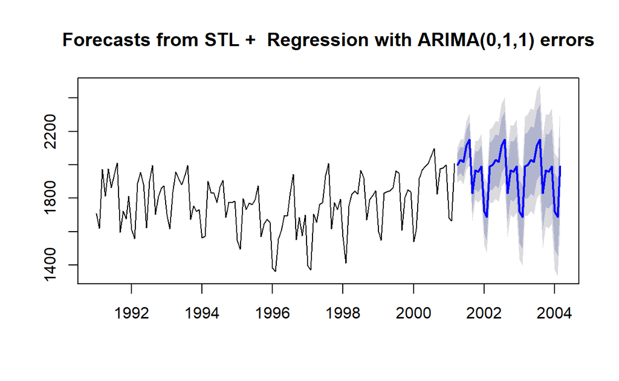

```
plot(STLM.forecast2)
```

```
accuracy(STLM.forecast2$mean, test.ts)
```

```
               ME     RMSE      MAE      MPE     MAPE     ACF1
Test set 38.04171 83.77231 70.30234 1.821433 3.555029 0.694755
         Theil's U
Test set 0.4885911
```